# Mapping migration with hex tiles

# Mapping migration with hex tiles

*This is based on [Rob Grant’s tutorial](http://rforjournalists.com/2017/07/20/internal-migration-part-i-hexagonal-maps-of-movement-of-people/)*

## Grab the data and combine

We’ve manually downloaded [two zip files](https://www.ons.gov.uk/peoplepopulationandcommunity/populationandmigration/migrationwithintheuk/datasets/internalmigrationbyoriginanddestinationlocalauthoritiessexandsingleyearofagedetailedestimatesdataset), unzipped them, and moved the CSV files into the same directory. Those steps could equally be done in R. But that takes us to Rob’s first piece of code:

```r
pt1 <- read.csv("Detailed_Estimates_2016_Dataset_1.csv")
pt2 <- read.csv("Detailed_Estimates_2016_Dataset_2.csv")
#join two together
data <- rbind(pt1, pt2)
```

Now to get the overview of the data with `str`:

```r
str(data)
```

```
'data.frame':   1282336 obs. of  5 variables:
 $ OutLA: Factor w/ 350 levels "E06000001","E06000002",..: 1 1 1 1 1 1 1 1 1 1 ...
 $ InLA : Factor w/ 350 levels "E06000001","E06000002",..: 2 2 2 2 2 2 2 2 2 2 ...
 $ Age  : int  0 1 3 5 5 6 7 8 8 9 ...
 $ Sex  : Factor w/ 2 levels "F","M": 1 1 1 2 1 1 2 2 1 1 ...
 $ Moves: num  0.669 2.512 1.254 1.275 1.221 ...
```

Now to install and activate the `dplyr` package:

```r
install.packages("dplyr")
```

```
Error in install.packages : Updating loaded packages
```

```r
library(dplyr)
```

## Create new aggregate data

With that library available, we can use some functions as outlined by Rob:

```r
first <- data %>%
group_by(OutLA, InLA) %>%
summarise (sum = sum(Moves))
LA_totals_in <- data %>%
group_by(InLA) %>%
summarise (sum = sum(Moves))
LA_totals_out <- data %>%
group_by(OutLA) %>%
summarise (sum = sum(Moves))
```

The `%>%` operator may be unfamiliar. This is an operator that `dplyr` borrowed from anoher package, `magrittr`, and [is explained here](https://stackoverflow.com/questions/23621209/differences-between-dplyr-and-magrittr). It is used “to pass the left hand side as an argument of the function on the right hand side”

Put another way, where the `<-` operator passes from right to left, `%>%` passes information in the other direction, from left to right. For more on dplyr [see this Data School introduction](http://www.dataschool.io/dplyr-tutorial-for-faster-data-manipulation-in-r/)

Let’s continue to creating some totals of net migration by subtracting the in and out numbers:

```r
LA_totals <- merge(LA_totals_in, LA_totals_out, by.x = "InLA", by.y = "OutLA")
 #calculate net figure
LA_totals$net <- LA_totals$sum.x - LA_totals$sum.y
```

## Import mapping libraries

Next Rob imports some mapping libraries. He doesn’t install the packages first, but you’ll probably need to:

```r
install.packages("rgdal")
```

```
Error in install.packages : Updating loaded packages
```

```r
library(rgdal)
#sp is a dependency of rgdal so doesn't need installing
library(sp)
install.packages("rgeos")
```

```
Error in install.packages : Updating loaded packages
```

```r
library(rgeos)
```

He also mentions a [link to a hexagonal map of local authorities](https://www.arcgis.com/home/item.html?id=593037bc399e460bb7c6c631ceff67b4). Hugely useful.

Download this, unzip, and put the files in the same place as this project. This code will throw an error if you are missing the .dbf, .shp or .shx files.

```r
#These two lines are missing from the first tutorial but can be found in the code in the second
hex <- readOGR(".","GB_Hex_Cartogram_LAs")
#This is adapted from the link in the example, but there is no shapefile function, so I've added two lines installing the raster package which includes that function
install.packages("raster")
```

```
Error in install.packages : Updating loaded packages
```

```r
library(raster)
p <- shapefile("GB_Hex_Cartogram_LAs.shp")
#Fill a new column with NA values - will be changed below.
LA_totals$color <- NA
```

Create a function to allocate colours:

```r
color <- function (a, b) {
  if (a >= 0) {
  b = "#0000FF"
  } else {
  b = "#ff80000"
  }
}
```

Rob writes: “An apply function (there are several, this one is mapply) takes a formula and applies it to several different values.” And that’s what happens next:

```r
#Note that a and b are used by the function above
LA_totals$color <- mapply(FUN = color, a = LA_totals$net, b = LA_totals$color)
```

The color column is overwritten with colour codes based on the figure in the net column.

Now we try to visualise this. It throws an error initially because the hexadecimal code in the function above is mistyped as `ff80000` (one too many zeroes). But when corrected, it works.

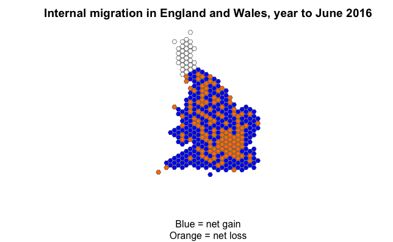

## Trying the second map

Converting NA to zeroes:

```r
net$sum.x <- mapply(FUN = na.zero, x = net$sum.x)
```

```
Error in mapply(FUN = na.zero, x = net$sum.x) : object 'net' not found
```

Install and activate more packages to split columns again:

```r
install.packages("tidyr")
install.packages("tidyr")
library(tidyr)
from_to <- net %>%
#separate using the space (sep)
separate(pair, into = c("from", "to"), sep = " ")
```

And now to plot it as a map:

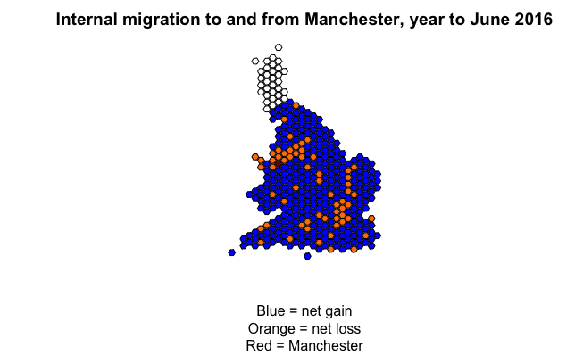